# 数学建模

### 模型知识点

### 常用概率分布

**Wang Haihua**

🚅 🚋😜 🚑 🚔

# 常用的概率分布

## 定长分布

定长分布简单来说就是，每一个顾客的服务时间都是定值。

## 均匀分布

在概率论和统计学中，均匀分布也叫矩形分布，它是对称概率分布，在相同长度间隔的分布概率是等可能的。 均匀分布由两个参数$a$和$b$定义，它们是数轴上的最小值和最大值，通常缩写为$U(a,b)$。

$$ f(x)=\begin{cases} \dfrac{1}{b-a}, a<x<b\\ 0 , else \end{cases} $$

```
(0.0, 1.2)
```

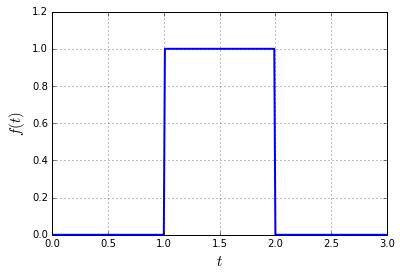

```python
def uniform(x,a,b):
    if (x > a) and (x < b):
        return 1/(b-a)
    else:
        return 0

import matplotlib.pyplot as plt
import numpy as np
plt.style.use('classic')
%matplotlib inline
a = 1
b = 2
t_list = [0.01 * i for i in range(300)]
ft = [uniform(t,a,b) for t in  t_list]
plt.plot(t_list, ft,linewidth = 2)
plt.xlabel(r'$t$',fontsize = 15)
plt.ylabel(r'$f(t)$',fontsize = 15)
#plt.text(4, 0.6, r'$f(t)=\lambda e^{-\lambda t}, \quad t>0$',fontsize = 20)
plt.grid()
plt.ylim([0,1.2])
```

## 正态分布

正态分布（Normal distribution），也称“常态分布”，又名高斯分布（Gaussian distribution），最早由A.棣莫弗在求二项分布的渐近公式中得到。C.F.高斯在研究测量误差时从另一个角度导出了它。P.S.拉普拉斯和高斯研究了它的性质。是一个在数学、物理及工程等领域都非常重要的概率分布，在统计学的许多方面有着重大的影响力。 正态曲线呈钟型，两头低，中间高，左右对称因其曲线呈钟形，因此人们又经常称之为钟形曲线。

$$ f(x)=\frac{1}{\sqrt{2 \pi} \sigma} \exp \left(-\frac{(x-\mu)^{2}}{2 \sigma^{2}}\right) $$

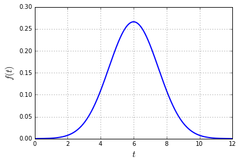

```python
mu = 6
sigma = 1.5
t_list = [0.01 * i for i in range(1200)]
ft = [ 1/np.sqrt(2*np.pi)/sigma * np.exp(-(t-mu)**2/2/sigma**2)       for t in t_list]
plt.plot(t_list, ft,linewidth = 2)
plt.xlabel(r'$t$',fontsize = 15)
plt.ylabel(r'$f(t)$',fontsize = 15)
plt.grid()
```

## 泊松分布

泊松分布又叫泊松流，在排队论中成为最简单流。

设$N(t)$表示在时间区间内$[t_0,t_0 + \Delta t)$内到达的顾客数，是随机变量。 当$N(t)$满足下列三个条件时，我们说顾客的到达符合泊松分布

1. 平稳性：在时间区间$[t_0,t_0 + \Delta t)$内到达的顾客数，只与时间区间长度$\Delta t$有关而与起点$t_0$无关
2. 无后效性：在时间区间$[t_0,t_0 + \Delta t)$内到达的顾客数，与$t_0$以前的顾客数独立
3. 普通性：在充分短的时间内$\Delta t$内，到达两个或者两个以上顾客的概率极小，可以忽略不计。

根据概率论的知识，满足以上三个条件的时候，可以推出在$t$时间段内有$n$个顾客到达服务系统的概率为

$$ P_{n}(t)=\frac{(\lambda t)^{n}}{n !} e^{-\lambda t} \quad n=0,1,2, \cdots $$

其中，$t \geq 0$ 代表时间长度。 $\lambda>0$为常数，表示单位时间到达的顾客数，即为到达率。

由于泊松流与实际生活中排队系统到达情况的相似性，目前排队论中的理论推导基本都是基于泊松流进行推导的。本课程的后续推导也将基于最简单流（泊松流）。

## 负指数分布

在概率论中，当顾客的到达服从泊松分布时，顾客到达的间隔时间必定服从负指数分布，负指数分布的概率密度函数为

$$ f(t)=\left\{\begin{array}{cc} {\lambda e^{-\lambda t},} & {t \geq 0} \\ {0,} & {t<0} \end{array}\right. $$

其中，$\lambda>0$与泊松分布一样，表示单位时间到达的顾客数，即为到达率。

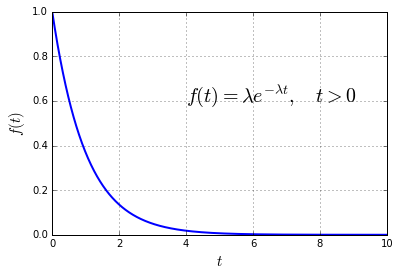

```python
Lambda = 1
t_list = [0.01 * i for i in range(1000)]
ft = [Lambda * np.exp(-Lambda * t) for t in t_list]
plt.plot(t_list, ft,linewidth = 2)
plt.xlabel(r'$t$',fontsize = 15)
plt.ylabel(r'$f(t)$',fontsize = 15)
plt.text(4, 0.6, r'$f(t)=\lambda e^{-\lambda t}, \quad t>0$',fontsize = 20)
plt.grid()
```

我们可以这么理解：**泊松分布和负指数分布，是从两个角度，对同一个现象进行的描述。**

- 泊松分布关注的是单位时间内到达（或者离去）的顾客个数
- 负指数分布关注的是顾客到达（或者离去）的时间间隔

## 爱尔朗分布

设$v_1,v_2,\cdots, v_k$是$k$个相互独立的随机变量，服从相同参数$k\lambda$的负指数分布，那么其求和后

$$ T = v_1 + v_2 + \cdots + v_k $$

的概率分布为

$$ f_{k}(t)=\frac{k \lambda(k \lambda t)^{k-1}}{(k-1) !} e^{-k \lambda t} \quad, \quad t \geq 0, \quad k \geq 0, \quad \lambda \geq 0 $$

上面的分布称为$k$阶爱尔朗分布。

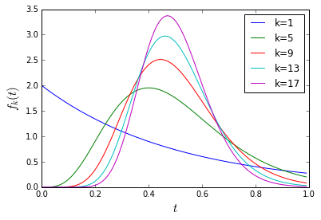

```python
import numpy as np

import matplotlib.pyplot as plt
plt.style.use('classic')
%matplotlib inline
def Erlang(t,Lambda,k):
    import numpy as np
    num = k*Lambda*(k*Lambda*t)**(k-1)* np.exp(-(k*Lambda*t))
    den = np.math.factorial(k-1)
    return  num/den

Lambda = 2
for k in range(1,20,4):
    t_list = [0.01 * t for t in range(100)]
    f_list = [Erlang(t,Lambda,k) for t in t_list]
    plt.plot(t_list,f_list,label = 'k=' +  str(k))
    plt.legend()
plt.xlabel(r'$t$',fontsize = 15)
plt.ylabel(r"$f_k(t)$",fontsize = 15)
```

- 当$k=1$时，爱尔朗分布就是指数分布
- $k$增大时，图形逐渐变为对称的
- $k \geq 30$时，近似于正态分布

我们可以根据原始资料，由顾客到达的规律，对$\lambda$的经验分布进行估计。

在后续讨论中，我们主要讨论$\lambda$的概率分布为**负指数分布**的情况。